# Communication

Creating Quarto Extensions

Author

Morgan Brucks

Published

July 29, 2026

**Assignment**. Create your own Quarto extension and practice what you have learned in the import, transform, visualize, and program chapters.

## Create Your Own Quarto Extension

1. Navigate to the **code** folder under your name in the **2026-RLAB-Practical-Exercises** folder.
2. Create an **_extensions** folder and a **rlab** folder inside extensions.
3. Create an **_extensions.yml** and **custom.css** file inside the **rlab** folder.
4. Add the following yaml to **_extensions.yml**:

```yaml
---
title: RLAB Quarto Format
author: Morgan Brucks
contributes:
  formats:
    html:
      title-block-banner: true
      theme: lumen
      css: custom.css
      embed-resources: true
      date-format: long
      code-copy: false
---
```

5. Add the format and extension to the yaml of the `communication.qmd` file.

```yaml
---
format:
  rlab-html: default
---
```

6. Copy the css from [this custom.css file](https://github.com/bhelsel/2026-RLAB-Practical-Exercises/tree/main/attendees/MorganBrucks/code/_extensions/rlab/custom.css) into the **custom.css** file that you just created.
7. *Optional*. Experiment with ths css styling in **custom.css** by changing the images, colors, font sizes, etc. to make it your own.

## Data Science Review

### Import Data

In this exercise, you will create an in-memory DuckDB database, copy the nycflights13 datasets into it, and use dplyr to create a new data frame for analysis.

**Step 1**

Create an in-memory DuckDB database by:

- Connecting to DuckDB with `DBI::dbConnect()`.
- Using **“:memory:”** as the database location.
- Copying the nycflights13 datasets into the database with `dbplyr::copy_nycflights13()`.

```r
con <- DBI::dbConnect(duckdb::duckdb(), dbdir = ":memory:")

dbplyr::copy_nycflights13(con)
```

**Step 2**

Using the tables stored in DuckDB, create a new object named flights that:

- Starts with the weather table.
- Selects only the origin, time_hour, temp, and wind_speed columns.
- Joins the flights table using both origin and time_hour as the matching variables.
- Collects the resulting data into your R session using collect().

After completing these steps, the flights object should contain the selected weather variables along with the matching flight information, ready for use in later exercises.

```r
flights <- dplyr::tbl(con, "weather") |>
  dplyr::select(origin, time_hour, temp, wind_speed) |>
  dplyr::inner_join(
    dplyr::tbl(con, "flights"),
    by = c("origin", "time_hour")
  ) |>
  dplyr::collect()
```

## Write Your Own Filter Function

Create a function named `custom_filter()` that filters a data frame based on a user-specified variable and value.

Your function should have three arguments:

- data: the data frame to filter.
- filter_by: the variable to use for filtering.
- value: the value to compare against.

Inside the function:

- Use `dplyr::filter()` to keep observations where the selected variable is greater than or equal to value.
- Use embracing ({{ }}) so that filter_by accepts an unquoted column name.

After writing your function, test it by creating a new object named filtered_flights that contains only rows where wind_speed is greater than or equal to 30 miles per hour.

If your function is written correctly, you should be able to call it by supplying a data frame, an unquoted variable name, and a comparison value.

```r
custom_filter <- function(data, filter_by, value) {
  data |>
    dplyr::filter({{ filter_by }} >= value)
}

filtered_flights <- custom_filter(flights, wind_speed, 30)
```

## Write Your Own Visualization Function

In this exercise, you will create a reusable function that produces a scatterplot using ggplot2. Your function should allow the user to choose the dataset, the variables to plot, and any optional arguments supported by ggplot2::geom_point().

**Step 1**

Create a function named `custom_visualization()` with four arguments:

1. data: the data frame to plot.
2. xvar: the variable to display on the x-axis.
3. yvar: the variable to display on the y-axis.
4. … additional arguments that will be passed directly to `ggplot2::geom_point()`.

**Step 2**

- Use `dplyr::filter()`.
- Inside filter(), use `dplyr::if_any()`.
- Use embracing ({{ }}) so that the function accepts unquoted variable names.
- The condition should only keep rows that do not have an NA.

**Hint**: The expression inside if_any() should refer to the range from xvar to yvar, and the predicate should be is.na.

**Step 3**

Pipe the filtered data into `ggplot2::ggplot()`.

Use ggplot2::aes() to map:

- x to xvar
- y to yvar
- Remember to use embracing ({{ }}) for both variables.

**Step 4**

Add a scatterplot layer using `ggplot2::geom_point()`.

Instead of specifying arguments like color or size yourself, forward all optional arguments using `...`. This allows users to customize the points by passing any arguments accepted by geom_point(), such as: color, size, shape, fill, alpha, stroke, etc.

**Step 5**

Test your function using the filtered_flights data frame. Create a scatterplot of:

- temp on the x-axis
- wind_speed on the y-axis

Customize the points by passing several optional arguments through …, for example:

color = “blue” size = 4 shape = 21 stroke = 2 fill = “red”

If your function is written correctly, these arguments should be passed automatically to ggplot2::geom_point() without modifying the function itself.

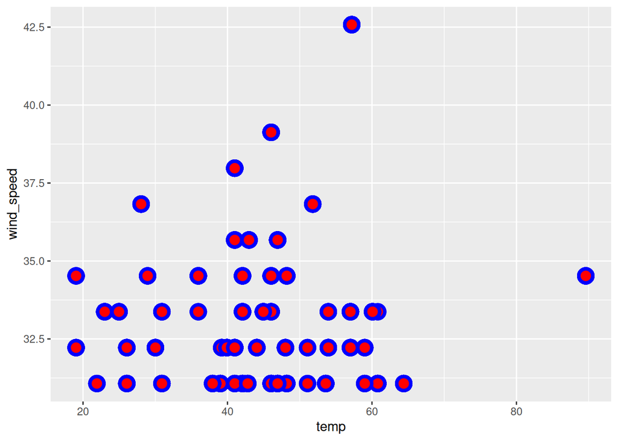

```r
custom_visualization <- function(data, xvar, yvar, ...) {
  data |>
    dplyr::filter(
      !dplyr::if_any({{ xvar }}:{{ yvar }}, is.na)
    ) |>
    ggplot2::ggplot(ggplot2::aes(x = {{ xvar }}, y = {{ yvar }})) +
    ggplot2::geom_point(...)
}

custom_visualization(
  filtered_flights,
  temp,
  wind_speed,
  color = "blue",
  size = 4,
  shape = 21,
  stroke = 2,
  fill = "red"
)
```